# Extracción de datos SoilGrids

Ejemplo Nitrógeno (15-30 cm) Colombia

[Edimer (Sidereus)](https://edimer.github.io/)

Abril de 2021

# Agradecimientos

- Agradezco enormemente a [Ivan Lizarazo](https://rpubs.com/ials2un) por su [documento guía](https://rpubs.com/ials2un/soilgrids_webdav) publicado en [Rpubs.](https://rpubs.com/) Sus documentos son muy valiosos para todos aquellos que como yo queremos aprender un poco acerca de Sistemas de Información Geográfica con R.

# SoilGrids

- [SoilGrids](https://soilgrids.org/)

[figure not shown]

# Bibliotecas

```r
library(rgdal)
library(gdalUtils)
library(raster)
library(sf)
library(tidyverse)
library(ggspatial)
```

# Raster Nitrógeno

- [Datos SoilGrids](https://files.isric.org/soilgrids/latest/data/)
- [ISRIC](https://www.isric.org/explore)
- [Artículo SoilGrids](https://journals.plos.org/plosone/article?id=10.1371/journal.pone.0169748)

```r
nitro <- raster("https://files.isric.org/soilgrids/latest/data/nitrogen/nitrogen_15-30cm_mean.vrt")
```

```r
nitro
```

```
class      : RasterLayer
dimensions : 58034, 159246, 9241682364  (nrow, ncol, ncell)
resolution : 250, 250  (x, y)
extent     : -19949750, 19861750, -6147500, 8361000  (xmin, xmax, ymin, ymax)
crs        : +proj=igh +lon_0=0 +x_0=0 +y_0=0 +datum=WGS84 +units=m +no_defs
source     : https://files.isric.org/soilgrids/latest/data/nitrogen/nitrogen_15-30cm_mean.vrt
names      : nitrogen_15.30cm_mean
values     : -32768, 32767  (min, max)
```

# Shape Colombia

- [Colombia Shape - Nivel geográfico departamentos](https://geoportal.dane.gov.co/servicios/descarga-y-metadatos/descarga-mgn-marco-geoestadistico-nacional/)

```r
deptos <- st_read("data_shapes/MGN_DPTO_POLITICO.shp")
```

- Proyección de coordenadas: transformación a [proyección homolosena de Goode](https://es.wikipedia.org/wiki/Proyecci%C3%B3n_de_Goode)

```r
igh <- '+proj=igh +lat_0=0 +lon_0=0 +datum=WGS84 +units=m +no_defs'
colombia_igh <- st_transform(deptos, igh)
```

```r
colombia_igh
```

```
Simple feature collection with 33 features and 9 fields
Geometry type: MULTIPOLYGON
Dimension:     XY
Bounding box:  xmin: -9147200 ymin: -470815.4 xmax: -7442381 ymax: 1491094
CRS:           +proj=igh +lat_0=0 +lon_0=0 +datum=WGS84 +units=m +no_defs
First 10 features:
   DPTO_CCDGO DPTO_CNMBR DPTO_ANO_C                                     DPTO_ACT_A DPTO_NAREA
1          05  ANTIOQUIA       1886                  Constitucion Politica de 1886   62804.71
2          23    CÓRDOBA       1951              Ley 9 del 18 de Diciembre de 1951   25086.55
3          27      CHOCÓ       1947              Ley 13 del 3 de Noviembre de 1947   48353.22
4          70      SUCRE       1966                 Ley 47 del 8 de Agosto de 1966   10591.85
5          08  ATLÁNTICO       1910                                 Ley 21 de 1910    3313.81
6          13    BOLÍVAR       1886                  Constitucion Politica de 1886   26719.21
7          47  MAGDALENA       1964                                           1964   23135.94
8          20      CESAR       1967                    Ley 25  21 de junio de 1967   22565.31
9          44 LA GUAJIRA       1964 Acto Legislativo No. 1 de Diciembre 28 de 1964   20619.01
10         19      CAUCA       1857                            15 de junio de 1857   31242.91
   DPTO_CSMBL DPTO_VGNC Shape_Leng  Shape_Area                       geometry
1           3      2020  2397127.4 64104708675 MULTIPOLYGON (((-8537745 98...
2           3      2020  1084739.0 25771851296 MULTIPOLYGON (((-8487485 10...
3           3      2020  2305005.9 49095252907 MULTIPOLYGON (((-8641428 96...
4           3      2020   960645.8 10927904055 MULTIPOLYGON (((-8449360 11...
5           3      2020   286201.3  3452348633 MULTIPOLYGON (((-8384559 12...
6           3      2020  1820039.5 27531715587 MULTIPOLYGON (((-8426196 12...
7           3      2020  1213551.0 24044561103 MULTIPOLYGON (((-8298708 12...
8           3      2020  1410287.8 23352037403 MULTIPOLYGON (((-8229790 12...
9           3      2020  1211484.9 21584067313 MULTIPOLYGON (((-8050536 13...
10          3      2020  1553621.4 31435492565 MULTIPOLYGON (((-8515823 37...
```

- Área de interés (Colombia):

```r
area <- st_bbox(colombia_igh)
area
```

```
      xmin       ymin       xmax       ymax
-9147200.3  -470815.4 -7442381.4  1491094.3
```

- Límites: formato numérico necesario para `rgdal`

```r
ulx <- area$xmin
uly <- area$ymax
lrx <- area$xmax
lry <- area$ymin
limites <- c(ulx, uly, lrx, lry)
limites
```

```
      xmin       ymax       xmax       ymin
-9147200.3  1491094.3 -7442381.4  -470815.4
```

# Nitrógeno Colombia (.tif)

- Obtención de datos con **GDAL**: este proceso se demora algunos minutos. Dará como resultado un archivo con formato *.tif* en la ruta especificada. **Importante:** es necesario tener instalado GDAL en nuestro computador (ver anexos para más información).

```r
sg_url <- "/vsicurl/https://files.isric.org/soilgrids/latest/data/nitrogen/nitrogen_15-30cm_mean.vrt"
lfile <- "data_shapes/nitrogeno_colombia.tif"

gdal_translate(sg_url, lfile ,
               tr = c(250,250),
               projwin = limites,
               projwin_srs = igh,
               verbose = TRUE)
```

```
Checking gdal_installation...
Scanning for GDAL installations...
Checking Sys.which...
GDAL version 3.2.2
GDAL command being used: "C:\Program Files\GDAL\gdal_translate.exe" -tr 250 250 -projwin -9147200.27432083 1491094.27369704 -7442381.38468577 -470815.374159958 -of "GTiff" -projwin_srs "+proj=igh +lat_0=0 +lon_0=0 +datum=WGS84 +units=m +no_defs" "/vsicurl/https://files.isric.org/soilgrids/latest/dat…
Input file size is 159246, 580340...10...20...30ERROR 1: Request for 390313-406512 failed...40...50...60...70...80...90...100 - done.
```

# Raster Nitrógeno Colombia

- [Consultar unidades del nitrógeno](https://www.isric.org/explore/soilgrids/faq-soilgrids#What_is_SoilGrids)

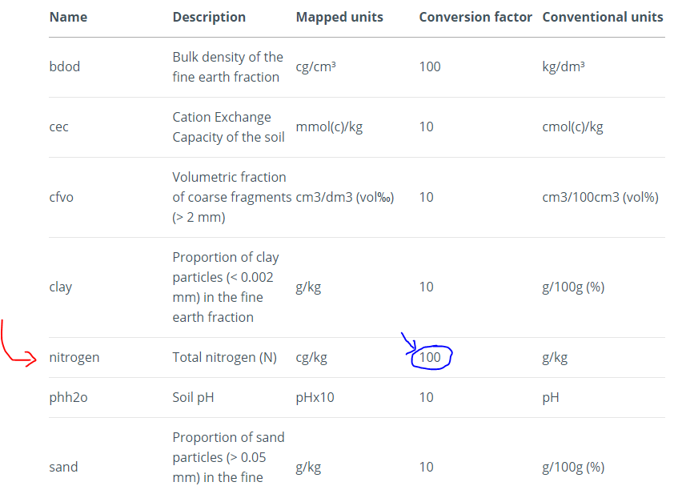

```r
nitro_colombia <- raster("data_shapes/nitrogeno_colombia.tif") / 100
```

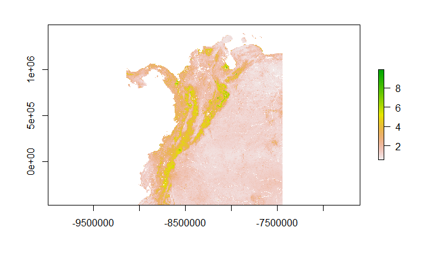

```r
plot(nitro_colombia)
```

# Corte Colombia

- Corte con el shape de Colombia que tiene el mismo tipo de coordenadas:

```r
corte_colombia <- nitro_colombia %>%
  crop(colombia_igh) %>%
  mask(colombia_igh)
```

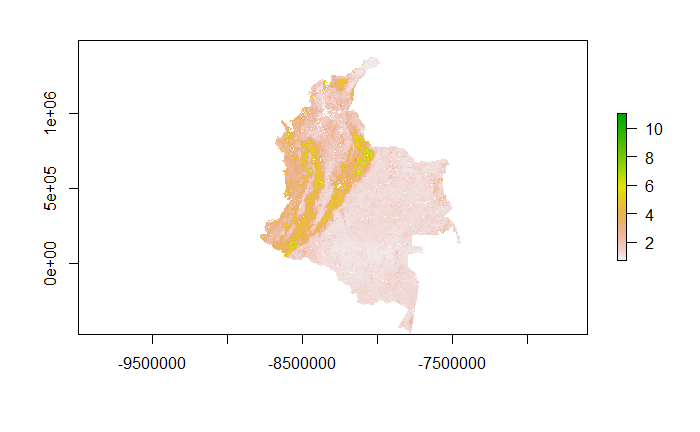

```r
plot(corte_colombia)
```

- Corte con shape obtenido con biblioteca `raster`:

```r
# Mapa Colombia
ejemplo <- getData(name = "GADM", country = "COL", level = 0)
```

```
probando la URL 'https://biogeo.ucdavis.edu/data/gadm3.6/Rsp/gadm36_COL_0_sp.rds'
```

```r
ejemplo_sf <- st_as_sf(ejemplo)

# Reproyección
ejemplo_igh <- st_transform(ejemplo_sf, igh)

# Corte
corte_ejemplo <- nitro_colombia %>%
  crop(ejemplo_igh) %>%
  mask(ejemplo_igh)
```

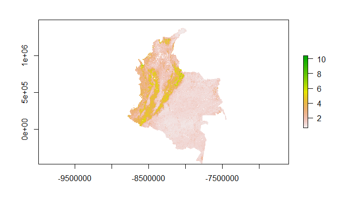

```r
plot(corte_ejemplo)
```

- Corte cambiando sistema de coordenadas:

```r
nuevo_sistema <- "+proj=longlat +datum=WGS84 +no_defs"
prueba <- projectRaster(nitro_colombia, crs = nuevo_sistema)

# Corte
prueba_ejemplo <- prueba %>%
  crop(ejemplo_sf) %>%
  mask(ejemplo_sf)
```

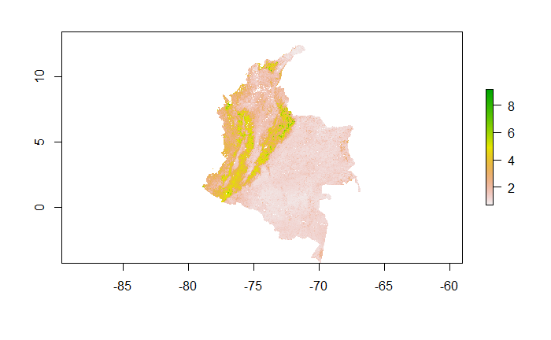

```r
plot(prueba_ejemplo)
```

# Valle del Cauca

## Filtro

```r
valle <- colombia_igh %>%
  filter(DPTO_CNMBR == "VALLE DEL CAUCA")
```

## Corte

```r
corte_valle <- nitro_colombia %>%
  crop(valle) %>%
  mask(valle)
```

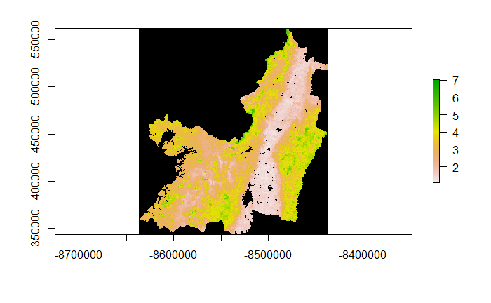

```r
plot(corte_valle, colNA = "black")
```